# ULLAS SD - ML MICRO PROJECT

#### 13. Data Cleaning

```python
data.head()
```

|  | Age | Attrition | BusinessTravel | DailyRate | Department | DistanceFromHome | Education | EducationField | EnvironmentSatisfaction | Gender | HourlyRate | JobInvolvement | JobLevel | JobRole | JobSatisfaction | MaritalStatus | MonthlyIncome | MonthlyRate | NumCompaniesWorked | OverTime | PercentSalaryHike | PerformanceRating | RelationshipSatisfaction | StockOptionLevel | TotalWorkingYears | TrainingTimesLastYear | WorkLifeBalance | YearsAtCompany | YearsInCurrentRole | … |
| --- | --- | --- | --- | --- | --- | --- | --- | --- | --- | --- | --- | --- | --- | --- | --- | --- | --- | --- | --- | --- | --- | --- | --- | --- | --- | --- | --- | --- | --- | --- |
| 0 | 41 | Yes | Travel_Rarely | 1102 | Sales | 1 | College | Life Sciences | Medium | Female | 94 | High | 2 | Sales Executive | Very High | Single | 5993 | 19479 | 8 | Yes | 11 | Excellent | Low | 0 | 8 | 0 | Bad | 6 | 4 | … |
| 1 | 49 | No | Travel_Frequently | 279 | Research & Development | 8 | Below College | Life Sciences | High | Male | 61 | Medium | 2 | Research Scientist | Medium | Married | 5130 | 24907 | 1 | No | 23 | Outstanding | Very High | 1 | 10 | 3 | Better | 10 | 7 | … |
| 2 | 37 | Yes | Travel_Rarely | 1373 | Research & Development | 2 | College | Other | Very High | Male | 92 | Medium | 1 | Laboratory Technician | High | Single | 2090 | 2396 | 6 | Yes | 15 | Excellent | Medium | 0 | 7 | 3 | Better | 0 | 0 | … |
| 3 | 33 | No | Travel_Frequently | 1392 | Research & Development | 3 | Master | Life Sciences | Very High | Female | 56 | High | 1 | Research Scientist | High | Married | 2909 | 23159 | 1 | Yes | 11 | Excellent | High | 0 | 8 | 3 | Better | 8 | 7 | … |
| 4 | 27 | No | Travel_Rarely | 591 | Research & Development | 2 | Below College | Medical | Low | Male | 40 | High | 1 | Laboratory Technician | Medium | Married | 3468 | 16632 | 9 | No | 12 | Excellent | Very High | 1 | 6 | 3 | Better | 2 | 2 | … |

```python
data['Attrition'].value_counts()
```

```
Attrition
No     763
Yes    154
Name: count, dtype: int64
```

```python
# Separate numerical and categorical features
numerical_features = data.select_dtypes(include=['float64', 'int64']).columns

categorical_features = data.select_dtypes(include=['object']).columns
```

```python
numerical_features
```

```
Index(['Age', 'DailyRate', 'DistanceFromHome', 'HourlyRate', 'JobLevel',
       'MonthlyIncome', 'MonthlyRate', 'NumCompaniesWorked',
       'PercentSalaryHike', 'StockOptionLevel', 'TotalWorkingYears',
       'TrainingTimesLastYear', 'YearsAtCompany', 'YearsInCurrentRole',
       'YearsSinceLastPromotion', 'YearsWithCurrManager'],
      dtype='object')
```

```python
categorical_features
```

```
Index(['Attrition', 'BusinessTravel', 'Department', 'Education',
       'EducationField', 'EnvironmentSatisfaction', 'Gender', 'JobInvolvement',
       'JobRole', 'JobSatisfaction', 'MaritalStatus', 'OverTime',
       'PerformanceRating', 'RelationshipSatisfaction', 'WorkLifeBalance'],
      dtype='object')
```

```python
numerical_data = data[numerical_features]
categorical_data = data[categorical_features]
```

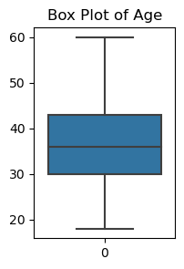

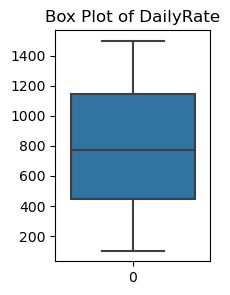

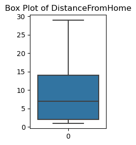

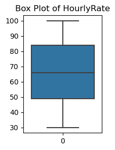

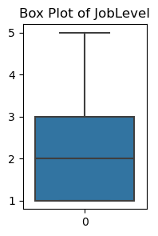

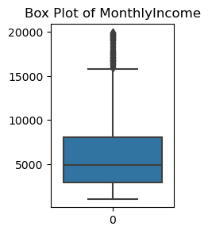

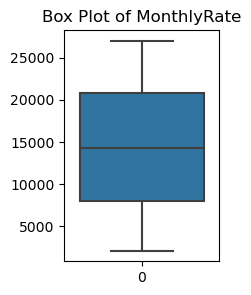

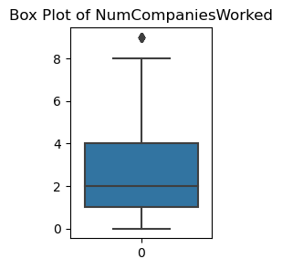

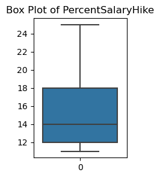

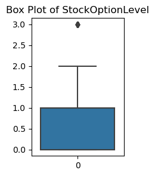

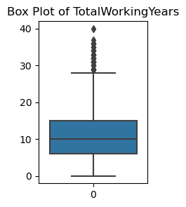

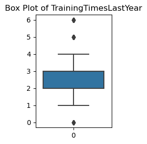

[4 more figures not shown]

```python
import matplotlib.pyplot as plt
import seaborn as sns

# Assuming 'data' is your DataFrame containing the dataset

# Step 1: Identify numerical columns
numerical_columns = data.select_dtypes(include=['int', 'float']).columns

# Step 2: Create box plots for each numerical column
for column in numerical_columns:
    plt.figure(figsize=(2, 3))
    sns.boxplot(data[column])
    plt.title(f'Box Plot of {column}')
    plt.show()
```

```python
z_scores = stats.zscore(numerical_data)
z_threshold = 3
outlier_mask = (z_scores > z_threshold).any(axis=1)
```

```python
outliers = numerical_data[outlier_mask]
```

```python
outliers.shape
```

```
(54, 16)
```

```python
outliers.head(10)
```

|  | Age | DailyRate | DistanceFromHome | HourlyRate | JobLevel | MonthlyIncome | MonthlyRate | NumCompaniesWorked | PercentSalaryHike | StockOptionLevel | TotalWorkingYears | TrainingTimesLastYear | YearsAtCompany | YearsInCurrentRole | YearsSinceLastPromotion | YearsWithCurrManager |
| --- | --- | --- | --- | --- | --- | --- | --- | --- | --- | --- | --- | --- | --- | --- | --- | --- |
| 8 | 52 | 621 | 3 | 31 | 4 | 16856 | 10084 | 1 | 11 | 0 | 34 | 3 | 34 | 6 | 1 | 16 |
| 31 | 42 | 570 | 8 | 66 | 5 | 18430 | 16225 | 1 | 13 | 1 | 24 | 4 | 24 | 7 | 14 | 9 |
| 39 | 47 | 202 | 2 | 33 | 4 | 16752 | 12982 | 1 | 11 | 1 | 26 | 3 | 26 | 14 | 3 | 0 |
| 42 | 58 | 286 | 2 | 31 | 5 | 19246 | 25761 | 7 | 12 | 0 | 40 | 2 | 31 | 15 | 13 | 8 |
| 63 | 51 | 1318 | 26 | 66 | 4 | 16307 | 5594 | 2 | 14 | 1 | 29 | 2 | 20 | 6 | 4 | 17 |
| 71 | 53 | 661 | 7 | 78 | 3 | 10934 | 20715 | 7 | 18 | 1 | 35 | 3 | 5 | 2 | 0 | 4 |
| 82 | 35 | 607 | 9 | 66 | 3 | 10685 | 23457 | 1 | 20 | 1 | 17 | 2 | 17 | 14 | 5 | 15 |
| 100 | 50 | 881 | 2 | 98 | 4 | 17924 | 4544 | 1 | 11 | 1 | 31 | 3 | 31 | 6 | 14 | 7 |
| 124 | 49 | 527 | 8 | 51 | 3 | 7403 | 22477 | 4 | 11 | 1 | 29 | 3 | 26 | 9 | 1 | 7 |
| 133 | 41 | 263 | 6 | 59 | 1 | 4721 | 3119 | 2 | 13 | 0 | 20 | 3 | 18 | 13 | 2 | 17 |

In this case i am not removing outliers because Removing outliers from the dataset can lead to the loss of valuable and meaningful information. Outliers often represent rare occurrences or extreme scenarios that are crucial for understanding the full range of variability within the data. By retaining outliers, we ensure that our analysis captures the complete picture, allowing for more insightful interpretations and more robust modeling outcomes.

```python
Y = data['Attrition']
df_feature = data.drop('Attrition', axis = 1)
```

```python
# filter the numerical features in the dataset
df_num = df_feature.select_dtypes(include = [np.number])

df_num.columns
```

```
Index(['Age', 'DailyRate', 'DistanceFromHome', 'HourlyRate', 'JobLevel',
       'MonthlyIncome', 'MonthlyRate', 'NumCompaniesWorked',
       'PercentSalaryHike', 'StockOptionLevel', 'TotalWorkingYears',
       'TrainingTimesLastYear', 'YearsAtCompany', 'YearsInCurrentRole',
       'YearsSinceLastPromotion', 'YearsWithCurrManager'],
      dtype='object')
```

```python
# filter the categorical features in the dataset
df_cat = df_feature.select_dtypes(include = [object])

df_cat.columns
```

```
Index(['BusinessTravel', 'Department', 'Education', 'EducationField',
       'EnvironmentSatisfaction', 'Gender', 'JobInvolvement', 'JobRole',
       'JobSatisfaction', 'MaritalStatus', 'OverTime', 'PerformanceRating',
       'RelationshipSatisfaction', 'WorkLifeBalance'],
      dtype='object')
```

```python
print(df_cat.dtypes)

dummy_var = pd.get_dummies(data=df_cat, drop_first=True, dtype=int)
```

```
BusinessTravel              object
Department                  object
Education                   object
EducationField              object
EnvironmentSatisfaction     object
Gender                      object
JobInvolvement              object
JobRole                     object
JobSatisfaction             object
MaritalStatus               object
OverTime                    object
PerformanceRating           object
RelationshipSatisfaction    object
WorkLifeBalance             object
dtype: object
```

```python
dummy_var.head(10)
```

|  | BusinessTravel_Travel_Frequently | BusinessTravel_Travel_Rarely | Department_Research & Development | Department_Sales | Education_Below College | Education_College | Education_Doctor | Education_Master | EducationField_Life Sciences | EducationField_Marketing | EducationField_Medical | EducationField_Other | EducationField_Technical Degree | EnvironmentSatisfaction_Low | EnvironmentSatisfaction_Medium | EnvironmentSatisfaction_Very High | Gender_Male | JobInvolvement_Low | JobInvolvement_Medium | JobInvolvement_Very High | JobRole_Human Resources | JobRole_Laboratory Technician | JobRole_Manager | JobRole_Manufacturing Director | JobRole_Research Director | JobRole_Research Scientist | JobRole_Sales Executive | JobRole_Sales Representative | JobSatisfaction_Low | … |
| --- | --- | --- | --- | --- | --- | --- | --- | --- | --- | --- | --- | --- | --- | --- | --- | --- | --- | --- | --- | --- | --- | --- | --- | --- | --- | --- | --- | --- | --- | --- |
| 0 | 0 | 1 | 0 | 1 | 0 | 1 | 0 | 0 | 1 | 0 | 0 | 0 | 0 | 0 | 1 | 0 | 0 | 0 | 0 | 0 | 0 | 0 | 0 | 0 | 0 | 0 | 1 | 0 | 0 | … |
| 1 | 1 | 0 | 1 | 0 | 1 | 0 | 0 | 0 | 1 | 0 | 0 | 0 | 0 | 0 | 0 | 0 | 1 | 0 | 1 | 0 | 0 | 0 | 0 | 0 | 0 | 1 | 0 | 0 | 0 | … |
| 2 | 0 | 1 | 1 | 0 | 0 | 1 | 0 | 0 | 0 | 0 | 0 | 1 | 0 | 0 | 0 | 1 | 1 | 0 | 1 | 0 | 0 | 1 | 0 | 0 | 0 | 0 | 0 | 0 | 0 | … |
| 3 | 1 | 0 | 1 | 0 | 0 | 0 | 0 | 1 | 1 | 0 | 0 | 0 | 0 | 0 | 0 | 1 | 0 | 0 | 0 | 0 | 0 | 0 | 0 | 0 | 0 | 1 | 0 | 0 | 0 | … |
| 4 | 0 | 1 | 1 | 0 | 1 | 0 | 0 | 0 | 0 | 0 | 1 | 0 | 0 | 1 | 0 | 0 | 1 | 0 | 0 | 0 | 0 | 1 | 0 | 0 | 0 | 0 | 0 | 0 | 0 | … |
| 5 | 1 | 0 | 1 | 0 | 0 | 0 | 0 | 1 | 1 | 0 | 0 | 0 | 0 | 1 | 0 | 0 | 1 | 0 | 0 | 0 | 0 | 1 | 0 | 0 | 0 | 0 | 0 | 0 | 0 | … |
| 6 | 0 | 1 | 1 | 0 | 0 | 0 | 1 | 0 | 0 | 0 | 1 | 0 | 0 | 0 | 0 | 1 | 1 | 0 | 0 | 0 | 0 | 0 | 0 | 0 | 0 | 1 | 0 | 0 | 0 | … |
| 7 | 0 | 1 | 1 | 0 | 0 | 0 | 1 | 0 | 1 | 0 | 0 | 0 | 0 | 0 | 1 | 0 | 0 | 0 | 0 | 0 | 0 | 0 | 0 | 1 | 0 | 0 | 0 | 0 | 1 | … |
| 8 | 0 | 1 | 0 | 1 | 0 | 0 | 0 | 1 | 0 | 1 | 0 | 0 | 0 | 0 | 0 | 0 | 1 | 0 | 1 | 0 | 0 | 0 | 1 | 0 | 0 | 0 | 0 | 0 | 1 | … |
| 9 | 0 | 1 | 1 | 0 | 0 | 0 | 0 | 1 | 0 | 0 | 0 | 1 | 0 | 0 | 0 | 1 | 1 | 0 | 0 | 0 | 0 | 0 | 0 | 0 | 0 | 1 | 0 | 0 | 0 | … |

#### 14. Scale the Data

```python
# initialize the standard scalar
X_scaler = StandardScaler()

# scale all the numerical columns
num_scaled = X_scaler.fit_transform(df_num)

# create a dataframe of scaled numerical variables
df_num_scaled = pd.DataFrame(num_scaled, columns = df_num.columns)
```

```python
df_num_scaled.head(10)
```

|  | Age | DailyRate | DistanceFromHome | HourlyRate | JobLevel | MonthlyIncome | MonthlyRate | NumCompaniesWorked | PercentSalaryHike | StockOptionLevel | TotalWorkingYears | TrainingTimesLastYear | YearsAtCompany | YearsInCurrentRole | YearsSinceLastPromotion | YearsWithCurrManager |
| --- | --- | --- | --- | --- | --- | --- | --- | --- | --- | --- | --- | --- | --- | --- | --- | --- |
| 0 | 0.452231 | 0.787410 | -1.025505 | 1.372893 | -0.040654 | -0.098085 | 0.702985 | 2.131617 | -1.158550 | -0.950320 | -0.407761 | -2.160414 | -0.163540 | -0.060512 | -0.676392 | 0.262741 |
| 1 | 1.343091 | -1.261470 | -0.160041 | -0.258630 | -0.040654 | -0.282385 | 1.458509 | -0.682047 | 2.139946 | 0.206975 | -0.151302 | 0.161187 | 0.508954 | 0.776013 | -0.361384 | 0.823052 |
| 2 | 0.006800 | 1.462071 | -0.901867 | 1.274013 | -0.949910 | -0.931600 | -1.674802 | 1.327713 | -0.059052 | -0.950320 | -0.535990 | 0.161187 | -1.172282 | -1.175878 | -0.676392 | -1.138036 |
| 3 | -0.438630 | 1.509372 | -0.778229 | -0.505831 | -0.949910 | -0.756696 | 1.215205 | -0.682047 | -1.158550 | -0.950320 | -0.407761 | 0.161187 | 0.172707 | 0.776013 | 0.268633 | -1.138036 |
| 4 | -1.106775 | -0.484738 | -0.901867 | -1.296872 | -0.949910 | -0.637318 | 0.306710 | 2.533569 | -0.883676 | 0.206975 | -0.664219 | 0.161187 | -0.836035 | -0.618195 | -0.046375 | -0.577725 |
| 5 | -0.549987 | -0.885552 | 1.818161 | 0.680731 | -0.040654 | -0.244159 | 0.935015 | -0.682047 | -0.059052 | 1.364271 | -0.151302 | -0.612680 | 0.508954 | 1.054854 | 0.583642 | 0.823052 |
| 6 | 0.118158 | -1.288855 | -0.901867 | 1.274013 | -0.949910 | -0.725090 | 0.841061 | 1.327713 | -0.608801 | 0.206975 | -0.664219 | -2.160414 | -1.004158 | -1.175878 | -0.676392 | -0.857880 |
| 7 | -0.327272 | -1.540297 | -0.160041 | -1.692393 | -0.040654 | -0.284308 | -1.425512 | 0.121857 | -0.333926 | 0.206975 | -0.535990 | 0.161187 | -1.172282 | -1.175878 | -0.676392 | -1.138036 |
| 8 | 1.677164 | -0.410052 | -0.778229 | -1.741833 | 1.777858 | 2.221788 | -0.604708 | -0.682047 | -1.158550 | -0.950320 | 2.926199 | 0.161187 | 4.543921 | 0.497171 | -0.361384 | 3.344450 |
| 9 | -0.438630 | -0.644068 | -1.025505 | -0.159750 | -0.949910 | -0.804320 | -1.283538 | -0.682047 | -0.608801 | -0.950320 | -0.151302 | -0.612680 | 0.508954 | 1.333696 | 1.528667 | 1.103207 |

#### Concatenate scaled numerical and dummy encoded categorical variables.

```python
# concat the dummy variables with numeric features to create a dataframe of all independent variables
X = pd.concat([df_num_scaled, dummy_var], axis = 1)

X.head()
```

|  | Age | DailyRate | DistanceFromHome | HourlyRate | JobLevel | MonthlyIncome | MonthlyRate | NumCompaniesWorked | PercentSalaryHike | StockOptionLevel | TotalWorkingYears | TrainingTimesLastYear | YearsAtCompany | YearsInCurrentRole | YearsSinceLastPromotion | YearsWithCurrManager | BusinessTravel_Travel_Frequently | BusinessTravel_Travel_Rarely | Department_Research & Development | Department_Sales | Education_Below College | Education_College | Education_Doctor | Education_Master | EducationField_Life Sciences | EducationField_Marketing | EducationField_Medical | EducationField_Other | EducationField_Technical Degree | … |
| --- | --- | --- | --- | --- | --- | --- | --- | --- | --- | --- | --- | --- | --- | --- | --- | --- | --- | --- | --- | --- | --- | --- | --- | --- | --- | --- | --- | --- | --- | --- |
| 0 | 0.452231 | 0.787410 | -1.025505 | 1.372893 | -0.040654 | -0.098085 | 0.702985 | 2.131617 | -1.158550 | -0.950320 | -0.407761 | -2.160414 | -0.163540 | -0.060512 | -0.676392 | 0.262741 | 0 | 1 | 0 | 1 | 0 | 1 | 0 | 0 | 1 | 0 | 0 | 0 | 0 | … |
| 1 | 1.343091 | -1.261470 | -0.160041 | -0.258630 | -0.040654 | -0.282385 | 1.458509 | -0.682047 | 2.139946 | 0.206975 | -0.151302 | 0.161187 | 0.508954 | 0.776013 | -0.361384 | 0.823052 | 1 | 0 | 1 | 0 | 1 | 0 | 0 | 0 | 1 | 0 | 0 | 0 | 0 | … |
| 2 | 0.006800 | 1.462071 | -0.901867 | 1.274013 | -0.949910 | -0.931600 | -1.674802 | 1.327713 | -0.059052 | -0.950320 | -0.535990 | 0.161187 | -1.172282 | -1.175878 | -0.676392 | -1.138036 | 0 | 1 | 1 | 0 | 0 | 1 | 0 | 0 | 0 | 0 | 0 | 1 | 0 | … |
| 3 | -0.438630 | 1.509372 | -0.778229 | -0.505831 | -0.949910 | -0.756696 | 1.215205 | -0.682047 | -1.158550 | -0.950320 | -0.407761 | 0.161187 | 0.172707 | 0.776013 | 0.268633 | -1.138036 | 1 | 0 | 1 | 0 | 0 | 0 | 0 | 1 | 1 | 0 | 0 | 0 | 0 | … |
| 4 | -1.106775 | -0.484738 | -0.901867 | -1.296872 | -0.949910 | -0.637318 | 0.306710 | 2.533569 | -0.883676 | 0.206975 | -0.664219 | 0.161187 | -0.836035 | -0.618195 | -0.046375 | -0.577725 | 0 | 1 | 1 | 0 | 1 | 0 | 0 | 0 | 0 | 0 | 1 | 0 | 0 | … |

```python
X.dtypes
```

```
Age                                   float64
DailyRate                             float64
DistanceFromHome                      float64
HourlyRate                            float64
JobLevel                              float64
MonthlyIncome                         float64
MonthlyRate                           float64
NumCompaniesWorked                    float64
PercentSalaryHike                     float64
StockOptionLevel                      float64
TotalWorkingYears                     float64
TrainingTimesLastYear                 float64
YearsAtCompany                        float64
YearsInCurrentRole                    float64
YearsSinceLastPromotion               float64
YearsWithCurrManager                  float64
BusinessTravel_Travel_Frequently        int32
BusinessTravel_Travel_Rarely            int32
Department_Research & Development       int32
Department_Sales                        int32
Education_Below College                 int32
Education_College                       int32
Education_Doctor                        int32
Education_Master                        int32
EducationField_Life Sciences            int32
EducationField_Marketing                int32
EducationField_Medical                  int32
EducationField_Other                    int32
EducationField_Technical Degree         int32
EnvironmentSatisfaction_Low             int32
EnvironmentSatisfaction_Medium          int32
EnvironmentSatisfaction_Very High       int32
Gender_Male                             int32
JobInvolvement_Low                      int32
JobInvolvement_Medium                   int32
JobInvolvement_Very High                int32
JobRole_Human Resources                 int32
JobRole_Laboratory Technician           int32
JobRole_Manager                         int32
JobRole_Manufacturing Director          int32
JobRole_Research Director               int32
JobRole_Research Scientist              int32
JobRole_Sales Executive                 int32
JobRole_Sales Representative            int32
JobSatisfaction_Low                     int32
JobSatisfaction_Medium                  int32
JobSatisfaction_Very High               int32
MaritalStatus_Married                   int32
MaritalStatus_Single                    int32
OverTime_Yes                            int32
PerformanceRating_Outstanding           int32
RelationshipSatisfaction_Low            int32
RelationshipSatisfaction_Medium         int32
RelationshipSatisfaction_Very High      int32
WorkLifeBalance_Best                    int32
WorkLifeBalance_Better                  int32
WorkLifeBalance_Good                    int32
dtype: object
```

#### Train-Test Split

```python
X = sm.add_constant(X)

X_train, X_test, y_train, y_test = train_test_split(X, Y, random_state = 10, test_size = 0.2)

print('X_train', X_train.shape)
print('y_train', y_train.shape)
print('X_test', X_test.shape)
print('y_test', y_test.shape)
```

```
X_train (733, 58)
y_train (733,)
X_test (184, 58)
y_test (184,)
```